# Practical Machine Learning Course Project

Augusto

05/02/2022

## Introduction to the data

The training data for this project are available here:

https://d396qusza40orc.cloudfront.net/predmachlearn/pml-training.csv

The test data are available here:

https://d396qusza40orc.cloudfront.net/predmachlearn/pml-testing.csv

### Load the data:

```r
# Make sure the data is in the same directory as this .rmd
dir_name <-dirname(rstudioapi::getSourceEditorContext()$path)
setwd(dir_name)
# Load data
pml.testing <- read.csv("pml-testing.csv", row.names = 1)
pml.training <- read.csv("pml-training.csv", row.names = 1)
# Give an overview of the data
dim(pml.training)
```

```
## [1] 19622   159
```

```r
dim(pml.testing)
```

```
## [1]  20 159
```

The training data contains 19622 observations of 159 variables. The test data contains 20 observations.

The goal of the project is to predict the manner in which participants did the exercise. This is the “classe” variable in the training set. Let’s have a look at the “classe” variable:

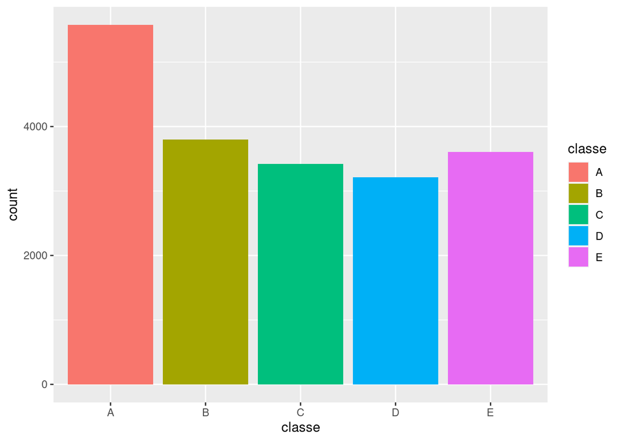

```r
library(ggplot2)
ggplot(data = pml.training, aes(classe, ..count..))+geom_bar(aes(fill = classe))
```

It seems that the classe variable contains an outcome of 5 possibilities, that appears at a relatively similar frequency, except classe “A” which seems more prevalent than the others.

### Splitting up the data

First we split the training dataset into a training and a validation set, in order to calculate the out of sample error down the line.

```r
library(caret)
set.seed(3980)
inTrain <- createDataPartition(y=pml.training$classe, p=0.8, list=F)
pml.train <- pml.training[inTrain, ]
pml.validate <- pml.training[-inTrain, ]
```

### Cleaning up the data

The data has a lot or variables. To reduce the number we check if any have near zero variance using the caret function. Those that do, we remove from the training dataset:

```r
nsv <- nearZeroVar(pml.train, saveMetrics = TRUE)
head(nsv)
```

```
##                      freqRatio percentUnique zeroVar   nzv
## user_name             1.064867    0.03821899   FALSE FALSE
## raw_timestamp_part_1  1.133333    5.33154978   FALSE FALSE
## raw_timestamp_part_2  1.000000   88.15211160   FALSE FALSE
## cvtd_timestamp        1.008340    0.12739665   FALSE FALSE
## new_window           49.479100    0.01273966   FALSE  TRUE
## num_window            1.133333    5.46531626   FALSE FALSE
```

```r
# Take the rows (columns in original data) that have near zero variance prediction
nzvp_rm<-rownames(nsv[nsv$nzv==TRUE,])

# Remove these variables from the training data
pml.train<-pml.train[,-which(colnames(pml.train) %in% nzvp_rm)]
dim(pml.train)
```

```
## [1] 15699   103
```

56 variables with near zero variance were removed, giving a training data set with 103 variables. After further inspection a lot of the column seem to have mainly NAs. Here we identify and remove those with > 80% NA values:

```r
NaColNames<-names(pml.train)[sapply(pml.train, function(x) sum(is.na(x)) > length(x)*0.8)]
pml.train<-pml.train[,-which(colnames(pml.train) %in% NaColNames)]
dim(pml.train)
```

```
## [1] 15699    58
```

Another 45 variables have been removed, leaving 58

### Model building

As we have categorical data that we want to predict (the “classe” variable) a powerful option is the random forest approach.

```r
# We start with random forest, with 3x cross validation. Don't print the training log
Control <- trainControl(method="cv", number=3, verboseIter=F)

# I will not run the traing of the model again. to save time, it has been stored in the object "pmlRF.rda" provided in the repo.
#RFfit <- train(classe ~ ., data=pml.train, method="rf",trControl=Control)
#save(RFfit, file = "pmlRF.rda")
load("pmlRF.rda")
```

Using the validation dataset that we split from our original training dataset, we can asses this model with a confusion matrix, giving an indication of out of sample accuracy:

```r
pred_RF <- predict(RFfit, pml.validate)
cmRF <- confusionMatrix(pred_RF, factor(pml.validate$classe))
cmRF
```

```
## Confusion Matrix and Statistics
##
##           Reference
## Prediction    A    B    C    D    E
##          A 1116    0    0    0    0
##          B    0  759    0    0    0
##          C    0    0  684    0    0
##          D    0    0    0  643    0
##          E    0    0    0    0  721
##
## Overall Statistics
##
##                Accuracy : 1
##                  95% CI : (0.9991, 1)
##     No Information Rate : 0.2845
##     P-Value [Acc > NIR] : < 2.2e-16
##
##                   Kappa : 1
##
##  Mcnemar's Test P-Value : NA
##
## Statistics by Class:
##
##                      Class: A Class: B Class: C Class: D Class: E
## Sensitivity            1.0000   1.0000   1.0000   1.0000   1.0000
## Specificity            1.0000   1.0000   1.0000   1.0000   1.0000
## Pos Pred Value         1.0000   1.0000   1.0000   1.0000   1.0000
## Neg Pred Value         1.0000   1.0000   1.0000   1.0000   1.0000
## Prevalence             0.2845   0.1935   0.1744   0.1639   0.1838
## Detection Rate         0.2845   0.1935   0.1744   0.1639   0.1838
## Detection Prevalence   0.2845   0.1935   0.1744   0.1639   0.1838
## Balanced Accuracy      1.0000   1.0000   1.0000   1.0000   1.0000
```

Suprisingly, this model has a 100% accuracy. Rather than develop more on our prediction model, we will use this initial Random Forest model to predict on our testing dataset:

```r
test_pred_RF <- predict(RFfit, pml.testing)
test_pred_RF
```

```
##  [1] B A B A A E D B A A B C B A E E A B B B
## Levels: A B C D E
```

We now have our 20 predictions of “classe” for our testing dataset. Plugging these into the project prediction quiz shows that they are all 20 correct.